# PRÁCTICA 4A: DETECCIÓN DE PLAGIO

PROFESOR: DR. LUIS GUILLERMO RUIZ VELÁZQUEZ

ESTUDIANTE: EDGAR SANTIAGO GONZALEZ MARTINEZ

# Introducción

Esta actividad se aborda la detección de posibles plagios entre dos colecciones de noticias en inglés: los textos fuente (`source-documents`) y los sospechosos (`suspicious-documents`). Se parte de que algunos documentos sospechosos podrían contener fragmentos tomados de las fuentes.

Se aplica lo siguiente: convertir todo a minúsculas, eliminar *stopwords* y realizar *stemming* con el algoritmo **Porter**. Al *stemming* también se aplica a la lista de *stopwords* para que el filtrado sea coherente con las formas normalizadas. Después, cada documento se representa como un conjunto de términos y la similitud entre pares se calcula con **Jaccard** y **Dice**, dos medidas basadas en el solapamiento del vocabulario.

La evaluación consiste en seleccionar **10** documentos de `source-documents` y, para cada uno, identificar los **10** textos de `suspicious-documents` más similares, reportando los nombres de archivo y los puntajes obtenidos con **Jaccard** y **Dice**.

# Conexión de Google Drive con Google Colab

Como primer procedimiento, se conecta Google Drive con Google Colab para poder acceder a los archivos almacenados en la nube.

La instrucción `from google.colab import drive` permite importar el módulo `drive`, el cual posibilita que Colab interactúe con Google Drive. El comando `drive.mount('/content/drive')` monta Google Drive en la carpeta `/content/drive`. Al ejecutarlo, Colab solicitará un permiso de acceso. Una vez concedido, los archivos estarán disponibles para lectura y escritura dentro del notebook.

```python
# Cargar Google Drive
from google.colab import drive
drive.mount('/content/drive')
```

# Instalación e importaciones

En esta parte dejamos listo el entorno para procesar texto. Primero actualiza **NLTK** con `!pip -q install nltk --upgrade`. Para garantizar que tenemos la versión reciente de **NLTK**.

```python
!pip -q install nltk --upgrade
```

```
   ━━━━━━━━━━━━━━━━━━━━━━━━━━━━━━━━━━━━━━━━ 1.5/1.5 MB 72.2 MB/s eta 0:00:00
```

Después se importan librerías base: `re` para usar **expresiones regulares**, `numpy` para **cálculos numéricos eficientes** y `pandas` para **organizar los documentos y resultados en DataFrames**. También se importa `Path` desde `pathlib`, que **facilita el manejo de rutas de archivos** de forma robusta.

Luego se carga `nltk` y se ejecuta `nltk.download('stopwords', quiet=True)` para **descargar el recurso de *stopwords*** en el entorno de ejecución.

A continuación se importan dos utilidades clave de **NLTK**. Con `from nltk.corpus import stopwords` se obtiene la lista de **palabras vacías** en inglés que se removerán, y con `from nltk.stem import PorterStemmer` se trae el **stemmer de Porter**, que **reduce palabras a su raíz**.

Finalmente, `from tqdm.auto import tqdm` añade una **barra de progreso automática** que se integra bien con notebooks.

```python
import re, numpy as np, pandas as pd
from pathlib import Path
import nltk
nltk.download('stopwords', quiet=True)

from nltk.corpus import stopwords
from nltk.stem import PorterStemmer
from tqdm.auto import tqdm
```

# Importación de archivos **source** y **suspicious**

En esta parte, se construye de forma ordenada y reproducible, los conjuntos de documentos **source** y **suspicious** a partir de las carpetas en Google Drive. Primero se define un patrón de expresión regular, `ID_RE = re.compile(r"(\d+)$")`, que busca una o más cifras al **final** del nombre base del archivo (por ejemplo, en `source-document0001.txt`, la parte `0001`). El prefijo `r"..."` indica cadena *raw* para que los metacaracteres se interpreten tal cual; los paréntesis capturan el grupo de dígitos y el símbolo `$` ancla la búsqueda al final de la cadena.

La función `get_id(p: Path) -> int` extrae ese identificador numérico desde `p.stem` es decir, el nombre del archivo sin la extensión `.txt`. Si encuentra un *match*, devuelve el entero correspondiente (`int(m.group(1))`); si no hay dígitos finales, retorna `-1`. Este ID es crucial para **ordenar numéricamente** los archivos.

Luego, `load_corpus(base_dir, prefix, collection)` recorre una carpeta y arma un **DataFrame** con los textos. Convierte la ruta base en un `Path`, lista todos los archivos cuyo nombre comienza con el prefijo indicado y termina en `.txt`, y los ordena por el ID numérico con `sorted(..., key=get_id)`. Para cada archivo, lee el contenido en UTF-8 y usa `errors="replace"` para no fallar si aparece algún carácter raro; despues se construye un registro con cinco campos: `collection` (etiqueta “source” o “suspicious”), `doc_id` (el número extraído del nombre), `name` (el nombre del archivo), `path` (la ruta completa) y `text` (el contenido). Al final convierte la lista en un **DataFrame**, lo ordena por `doc_id` y reinicia el índice, dejándolo listo para análisis posteriores.

Finalmente se especifican las rutas de trabajo para cada colección (`SRC_BASE` y `SUS_BASE`) y se crean dos **DataFrames**: `df_source` y `df_suspicious`, llamando a `load_corpus` con los prefijos correctos (`"source-document"` y `"suspicious-document"`). La última línea, `len(df_source), len(df_suspicious)`, devuelve un par con los conteos leídos, útil como **verificación rápida** de que la carga fue completa (237 para *source* y 2370 para *suspicious*).

```python
ID_RE = re.compile(r"(\d+)$")
def get_id(p: Path) -> int:
    m = ID_RE.search(p.stem)
    return int(m.group(1)) if m else -1
def load_corpus(base_dir: str, prefix: str, collection: str) -> pd.DataFrame:
    base = Path(base_dir)
    files = sorted(base.glob(f"{prefix}*.txt"), key=get_id)
    rows = []
    for p in files:
        txt = p.read_text(encoding="utf-8", errors="replace")
        rows.append({
            "collection": collection,
            "doc_id": get_id(p),
            "name": p.name,
            "path": str(p),
            "text": txt})
    return pd.DataFrame(rows).sort_values("doc_id").reset_index(drop=True)
SRC_BASE = "/content/drive/MyDrive/MCDI/4a/source-documents"
SUS_BASE = "/content/drive/MyDrive/MCDI/4a/suspicious-documents"
df_source     = load_corpus(SRC_BASE, "source-document",     "source")
df_suspicious = load_corpus(SUS_BASE,  "suspicious-document", "suspicious")

len(df_source), len(df_suspicious)
```

```
(237, 2370)
```

# Preprocesamiento y limpieza de los archivos.

Este bloque define el **preprocesamiento léxico** previo a medir similitudes. Se crea el **stemmer de Porter** (`STEMMER = PorterStemmer()`), se cargan las *stopwords* de NLTK (`stopwords.words('english')`) y **se les aplica el mismo stemming** para obtener `STOP_STEMMED`. Así, al stemmear también los textos, el filtrado de palabras vacías es coherente con las formas normalizadas.

Luego se compila `TOKEN_RE = re.compile(r"[a-z]+")` para tokenizar solo **secuencias de letras minúsculas** (a–z), descartando números y signos. La función `preprocess_to_tokens` aplica: (1) **minúsculas**, (2) **tokenización** con la regex, (3) **stemming** de Porter y (4) **filtrado** de *stopwords* ya stemmeadas y **tokens de 1 letra**. Devuelve una lista de **raíces** lista para construir conjuntos o bolsas de palabras.

```python
STEMMER = PorterStemmer()
STOP_RAW = set(stopwords.words('english'))
STOP_STEMMED = {STEMMER.stem(w) for w in STOP_RAW}
TOKEN_RE = re.compile(r"[a-z]+")

def preprocess_to_tokens(text: str):
    t = text.lower()
    toks = TOKEN_RE.findall(t)
    stems = [STEMMER.stem(w) for w in toks]
    stems = [s for s in stems if s not in STOP_STEMMED and len(s) > 1]
    return stems
```

# Representación como conjuntos para Jaccard/Dice

Este bloque convierte cada documento en un **conjunto de términos únicos** (stems) y, si se desea, añade **n-gramas**. Luego crea dos listas de conjuntos (una para *source* y otra para *suspicious*) y guarda sus **tamaños** para acelerar cálculos.

- `build_token_set(text, ngram_range=(1,1))` usa `preprocess_to_tokens` (minúsculas, sin *stopwords*, con *stemming* Porter) y construye `bag = set(toks)` (unigramas). Si `ngram_range` pide más, agrega bigramas/trigramas con `to_ngrams` mediante unión de sets.
- Se aplica a todos los documentos: `src_sets` para `df_source["text"]` y `sus_sets` para `df_suspicious["text"]`. `tqdm(...)` solo muestra una **barra de progreso**. Con `(1,1)` usas unigramas; para captar frases cortas, cambia a `(1,2)` (requiere `to_ngrams`).
- `src_sizes` y `sus_sizes` almacenan el **número de elementos** de cada set. Sirven para calcular la **unión** como `|A| + |B| − |A∩B|` sin recomputar longitudes.

Con este proceso dejamos cada documento listo para **Jaccard** y **Dice**, con opción de n-gramas y cacheo de tamaños para mayor eficiencia.

```python
def build_token_set(text: str, ngram_range=(1,1)):
    toks = preprocess_to_tokens(text)
    bag = set(toks)
    if ngram_range[1] >= 2:
        for n in range(max(2, ngram_range[0]), ngram_range[1]+1):
            bag |= set(to_ngrams(toks, n=n))
    return bag
# Construye sets para source y suspicious
src_sets = [build_token_set(t, ngram_range=(1,1)) for t in tqdm(df_source["text"], desc="source→sets")]
sus_sets = [build_token_set(t, ngram_range=(1,1)) for t in tqdm(df_suspicious["text"], desc="suspicious→sets")]
# Longitudes precomputadas (para rapidez)
src_sizes = np.array([len(s) for s in src_sets], dtype=int)
sus_sizes = np.array([len(s) for s in sus_sets], dtype=int)
```

# Medidas Jaccard y Dice

Este bloque implementa, sobre **conjuntos de términos** (stems), las dos medidas pedidas: **Jaccard** y **Dice**. La idea es comparar documentos por **presencia/ausencia** de términos, no por frecuencia; por eso antes se transformó cada texto en un *set* de términos únicos.

Primero, `sim_sizes(a_set, b_set)` calcula el tamaño de la **intersección** con `a_set & b_set` y devuelve también el tamaño de la **unión** sin construirla explícitamente:

$$|A \cup B| = |A| + |B| - |A \cap B|.$$

Esta identidad evita crear objetos intermedios y ahorra memoria/tiempo cuando los *sets* son grandes.

Con esa ayuda, `jaccard(a_set, b_set)` calcula:

$$J(A,B)=\frac{|A \cap B|}{|A \cup B|}.$$

Si la unión fuera cero, devuelve `0.0` para evitar división entre cero.

Por su parte, `dice(a_set, b_set)` calcula directamente:

$$D(A,B)=\frac{2\,|A \cap B|}{|A| + |B|}.$$

También varía de 0 a 1 y crece con el solapamiento.

Con esto, ambas métricas operan sobre **sets** (presencia/ausencia), no sobre conteos. Por eso el preprocesamiento convirtió cada documento en un conjunto de términos únicos.

- El operador `&` calcula la **intersección de sets** en tiempo aproximado a
  $$O\big(\min(|A|,\,|B|)\big).$$
- Reutilizar el valor de la intersección (`inter`) en Jaccard y Dice evita trabajo duplicado.
- Existe una relación directa entre ambas métricas:
  $$D=\frac{2J}{1+J}.$$ Por eso **Dice** suele ser numéricamente **mayor** que **Jaccard** para un mismo par.
- Asegúrate de que `a_set` y `b_set` sean realmente de tipo `set` (no `list` ni `tuple`), para que `&` y los cálculos de tamaño funcionen como se espera.
- Si tras el preprocesamiento un documento queda **vacío**, ambas funciones devuelven `0.0` al compararlo.

```python
def sim_sizes(a_set, b_set):
    inter = len(a_set & b_set)
    return inter, len(a_set) + len(b_set) - inter

def jaccard(a_set, b_set):
    inter, union = sim_sizes(a_set, b_set)
    return 0.0 if union == 0 else inter / union

def dice(a_set, b_set):
    inter = len(a_set & b_set)
    denom = len(a_set) + len(b_set)
    return 0.0 if denom == 0 else (2.0 * inter) / denom
```

# Top de **suspicious** por cada source

Estas funciones arma el **ranking de similitud** entre cada documento *source* y todos los *suspicious*, y devuelve una **tabla ordenada** con los **10 más parecidos** por *source* usando **Jaccard** y reportando también **Dice**.

Primero, `topk_for_source_index(src_i, k)` recibe el **índice interno** de un documento en `df_source`. Recupera su conjunto de términos `A = src_sets[src_i]` y recorre todos los conjuntos de *suspicious* (`sus_sets`). Para cada uno calcula **Jaccard** y **Dice**, acumulando los valores en dos listas que luego convierte a arreglos de NumPy (`sims_j`, `sims_d`).  
Con eso listo, selecciona eficientemente los **k** mayores de Jaccard: usa `np.argpartition(-sims_j, range(k))[:k]` para obtener —en **tiempo casi lineal**— los índices de los candidatos *top-k* sin ordenar todo el vector; después **ordena solo esos k** por puntaje descendente con `np.argsort(-sims_j[top])`.  
Por cada índice seleccionado, construye un renglón con metadatos legibles (IDs y **nombres de archivo** tomados de `df_source` y `df_suspicious`) y los puntajes de **Jaccard/Dice**, junto con el **rank** (1 = más similar). Devuelve la lista de renglones para ese *source*.

La función `topk_for_source_ids(source_ids, k)` es un **contenedor** para trabajar por **IDs de documento**. Primero crea un **mapa** `doc_id → índice interno` en `df_source`. Luego, para cada `sid`, busca su índice `src_i`, llama a `topk_for_source_index(src_i, k)` y **acumula** todos los renglones. Al final convierte la lista en un **DataFrame**, lo **ordena** por `source_id, rank` y **reinicia** el índice.

```python
def topk_for_source_index(src_i: int, k: int = 10):
    A = src_sets[src_i]
    sims_j = []
    sims_d = []
    for B in sus_sets:
        sims_j.append(jaccard(A, B))
        sims_d.append(dice(A, B))
    sims_j = np.asarray(sims_j)
    sims_d = np.asarray(sims_d)
    # orden por Jaccard descendente
    k = min(k, len(sims_j))
    top = np.argpartition(-sims_j, range(k))[:k]
    top = top[np.argsort(-sims_j[top])]
    rows = []
    for rank, j in enumerate(top, 1):
        rows.append({
            "source_id": int(df_source.iloc[src_i]["doc_id"]),
            "source_name": df_source.iloc[src_i]["name"],
            "suspicious_id": int(df_suspicious.iloc[j]["doc_id"]),
            "suspicious_name": df_suspicious.iloc[j]["name"],
            "jaccard": float(sims_j[j]),
            "dice": float(sims_d[j]),
            "rank": rank
        })
    return rows
def topk_for_source_ids(source_ids, k=10):
    index_by_id = {int(r.doc_id): i for i, r in df_source.reset_index().iterrows()}
    all_rows = []
    for sid in source_ids:
        src_i = index_by_id[int(sid)]
        all_rows.extend(topk_for_source_index(src_i, k=k))
    return pd.DataFrame(all_rows).sort_values(["source_id","rank"]).reset_index(drop=True)
```

# Ejecutar Top 10 de source

Este bloque genera la **tabla** de resultados.

- `sample_source = df_source["doc_id"].head(10).tolist()`  
  Toma los **primeros 10 `doc_id`** de *source* según el orden del DataFrame.
- `resultados = topk_for_source_ids(sample_source, k=10)`  
  Para **cada** uno de esos 10 *source*, calcula los **10 suspicious más similares** por **Jaccard** y también reporta **Dice**. La función devuelve una **tabla ordenada** por `source_id` y `rank`, con **nombres de archivo** y **puntajes**.
- Formato legible de puntajes:  
  `resultados["jaccard"] = resultados["jaccard"].round(4)` y `resultados["dice"] = resultados["dice"].round(4)`

```python
sample_source = df_source["doc_id"].head(10).tolist()
resultados = topk_for_source_ids(sample_source, k=10)
resultados["jaccard"] = resultados["jaccard"].round(4)
resultados["dice"]    = resultados["dice"].round(4)
```

# Resultados

Por último, se presentan los resultados en bloques de 10. Para cada documento *source* se listan sus **10 documentos sospechosos** con mayor similitud, ordenados por **rank** del más parecido.

En la primera tabla, el **máximo nivel de similitud** para `source-document0001.txt` lo presenta `suspicious-document0010.txt` (Jaccard **0.1871**, Dice **0.3152**), lo que indica el mayor solapamiento de vocabulario del conjunto.

El resto del **top-10** es **muy compacto**: los siguientes candidatos (`#2205`, `#2048`, `#2121`) están ~0.01 por debajo y el rango completo va de **0.1871** a **0.1722** (Dice ≈ **0.29–0.32**).

```python
resultados.iloc[0:10]
```

|  | source_id | source_name | suspicious_id | suspicious_name | jaccard | dice | rank |
| --- | --- | --- | --- | --- | --- | --- | --- |
| 0 | 1 | source-document0001.txt | 10 | suspicious-document0010.txt | 0.1871 | 0.3152 | 1 |
| 1 | 1 | source-document0001.txt | 2205 | suspicious-document2205.txt | 0.1782 | 0.3024 | 2 |
| 2 | 1 | source-document0001.txt | 2048 | suspicious-document2048.txt | 0.1769 | 0.3006 | 3 |
| 3 | 1 | source-document0001.txt | 2121 | suspicious-document2121.txt | 0.1762 | 0.2996 | 4 |
| 4 | 1 | source-document0001.txt | 1267 | suspicious-document1267.txt | 0.1741 | 0.2966 | 5 |
| 5 | 1 | source-document0001.txt | 2167 | suspicious-document2167.txt | 0.1729 | 0.2948 | 6 |
| 6 | 1 | source-document0001.txt | 2025 | suspicious-document2025.txt | 0.1727 | 0.2945 | 7 |
| 7 | 1 | source-document0001.txt | 1402 | suspicious-document1402.txt | 0.1724 | 0.2941 | 8 |
| 8 | 1 | source-document0001.txt | 2103 | suspicious-document2103.txt | 0.1722 | 0.2938 | 9 |
| 9 | 1 | source-document0001.txt | 2148 | suspicious-document2148.txt | 0.1722 | 0.2938 | 10 |

La **segunda tabla** (para `source-document0002.txt`) ubica como principal candidato a `suspicious-document0020.txt` con **Jaccard = 0.1380** y **Dice = 0.2426**. Es el mayor solapamiento observado para este *source*, aunque menor que en el caso anterior.

El resto del **top-10** queda entre **0.1263** y **0.1102**, con una brecha total de **0.0278** y un **bloque muy parejo** alrededor de **0.111–0.113**.

```python
resultados.iloc[10:20]
```

|  | source_id | source_name | suspicious_id | suspicious_name | jaccard | dice | rank |
| --- | --- | --- | --- | --- | --- | --- | --- |
| 10 | 2 | source-document0002.txt | 20 | suspicious-document0020.txt | 0.1380 | 0.2426 | 1 |
| 11 | 2 | source-document0002.txt | 19 | suspicious-document0019.txt | 0.1263 | 0.2243 | 2 |
| 12 | 2 | source-document0002.txt | 1463 | suspicious-document1463.txt | 0.1160 | 0.2079 | 3 |
| 13 | 2 | source-document0002.txt | 1145 | suspicious-document1145.txt | 0.1129 | 0.2030 | 4 |
| 14 | 2 | source-document0002.txt | 2050 | suspicious-document2050.txt | 0.1126 | 0.2025 | 5 |
| 15 | 2 | source-document0002.txt | 1603 | suspicious-document1603.txt | 0.1126 | 0.2025 | 6 |
| 16 | 2 | source-document0002.txt | 1120 | suspicious-document1120.txt | 0.1117 | 0.2009 | 7 |
| 17 | 2 | source-document0002.txt | 1088 | suspicious-document1088.txt | 0.1111 | 0.2000 | 8 |
| 18 | 2 | source-document0002.txt | 1411 | suspicious-document1411.txt | 0.1111 | 0.2000 | 9 |
| 19 | 2 | source-document0002.txt | 13 | suspicious-document0013.txt | 0.1102 | 0.1986 | 10 |

La **tercera tabla** (para `source-document0003.txt`) señala como principal similitud `suspicious-document0030.txt` con **Jaccard = 0.1949** (Dice **0.3262**), seguido por `suspicious-document0029.txt` con **0.1813** (Dice **0.3069**). Ambos muestran el mayor solapamiento de vocabulario.

```python
resultados.iloc[20:30]
```

|  | source_id | source_name | suspicious_id | suspicious_name | jaccard | dice | rank |
| --- | --- | --- | --- | --- | --- | --- | --- |
| 20 | 3 | source-document0003.txt | 30 | suspicious-document0030.txt | 0.1949 | 0.3262 | 1 |
| 21 | 3 | source-document0003.txt | 29 | suspicious-document0029.txt | 0.1813 | 0.3069 | 2 |
| 22 | 3 | source-document0003.txt | 22 | suspicious-document0022.txt | 0.1111 | 0.2000 | 3 |
| 23 | 3 | source-document0003.txt | 1000 | suspicious-document1000.txt | 0.1099 | 0.1981 | 4 |
| 24 | 3 | source-document0003.txt | 23 | suspicious-document0023.txt | 0.1086 | 0.1959 | 5 |
| 25 | 3 | source-document0003.txt | 2324 | suspicious-document2324.txt | 0.1011 | 0.1837 | 6 |
| 26 | 3 | source-document0003.txt | 2347 | suspicious-document2347.txt | 0.1006 | 0.1829 | 7 |
| 27 | 3 | source-document0003.txt | 1734 | suspicious-document1734.txt | 0.1003 | 0.1823 | 8 |
| 28 | 3 | source-document0003.txt | 27 | suspicious-document0027.txt | 0.1002 | 0.1822 | 9 |
| 29 | 3 | source-document0003.txt | 818 | suspicious-document0818.txt | 0.1002 | 0.1821 | 10 |

La **cuarta tabla** (para `source-document0004.txt`) sitúa como parentesco a `suspicious-document0040.txt` con **Jaccard = 0.1790** (Dice **0.3037**). Le siguen muy de cerca `#0039` (**0.1713**), `#0033` (**0.1703**) y `#0031` (**0.1682**): el **top-4** queda en un margen estrecho (≈0.011).

```python
resultados.iloc[30:40]
```

|  | source_id | source_name | suspicious_id | suspicious_name | jaccard | dice | rank |
| --- | --- | --- | --- | --- | --- | --- | --- |
| 30 | 4 | source-document0004.txt | 40 | suspicious-document0040.txt | 0.1790 | 0.3037 | 1 |
| 31 | 4 | source-document0004.txt | 39 | suspicious-document0039.txt | 0.1713 | 0.2925 | 2 |
| 32 | 4 | source-document0004.txt | 33 | suspicious-document0033.txt | 0.1703 | 0.2910 | 3 |
| 33 | 4 | source-document0004.txt | 31 | suspicious-document0031.txt | 0.1682 | 0.2879 | 4 |
| 34 | 4 | source-document0004.txt | 151 | suspicious-document0151.txt | 0.1528 | 0.2651 | 5 |
| 35 | 4 | source-document0004.txt | 142 | suspicious-document0142.txt | 0.1508 | 0.2620 | 6 |
| 36 | 4 | source-document0004.txt | 73 | suspicious-document0073.txt | 0.1504 | 0.2614 | 7 |
| 37 | 4 | source-document0004.txt | 12 | suspicious-document0012.txt | 0.1499 | 0.2607 | 8 |
| 38 | 4 | source-document0004.txt | 102 | suspicious-document0102.txt | 0.1499 | 0.2607 | 9 |
| 39 | 4 | source-document0004.txt | 82 | suspicious-document0082.txt | 0.1498 | 0.2606 | 10 |

La **quinta tabla** (para `source-document0005.txt`) muestra un **claramente destacado**: `suspicious-document0049.txt` con **Jaccard = 0.1957** (Dice **0.3273**). La **brecha con el segundo lugar** es amplia (**0.0584**), mucho mayor que en los casos previos.

```python
resultados.iloc[40:50]
```

|  | source_id | source_name | suspicious_id | suspicious_name | jaccard | dice | rank |
| --- | --- | --- | --- | --- | --- | --- | --- |
| 40 | 5 | source-document0005.txt | 49 | suspicious-document0049.txt | 0.1957 | 0.3273 | 1 |
| 41 | 5 | source-document0005.txt | 50 | suspicious-document0050.txt | 0.1373 | 0.2415 | 2 |
| 42 | 5 | source-document0005.txt | 44 | suspicious-document0044.txt | 0.1325 | 0.2340 | 3 |
| 43 | 5 | source-document0005.txt | 1779 | suspicious-document1779.txt | 0.1294 | 0.2291 | 4 |
| 44 | 5 | source-document0005.txt | 2070 | suspicious-document2070.txt | 0.1291 | 0.2287 | 5 |
| 45 | 5 | source-document0005.txt | 1367 | suspicious-document1367.txt | 0.1195 | 0.2134 | 6 |
| 46 | 5 | source-document0005.txt | 1795 | suspicious-document1795.txt | 0.1124 | 0.2021 | 7 |
| 47 | 5 | source-document0005.txt | 1748 | suspicious-document1748.txt | 0.1122 | 0.2017 | 8 |
| 48 | 5 | source-document0005.txt | 45 | suspicious-document0045.txt | 0.1121 | 0.2016 | 9 |
| 49 | 5 | source-document0005.txt | 43 | suspicious-document0043.txt | 0.1113 | 0.2004 | 10 |

La **sexta tabla** (para `source-document0006.txt`) muestra dos muy similares prácticamente iguales: `suspicious-document0060.txt` (Jaccard **0.1642**, Dice **0.2821**) y `suspicious-document0059.txt` (**0.1639**, **0.2816**).

```python
resultados.iloc[50:60]
```

|  | source_id | source_name | suspicious_id | suspicious_name | jaccard | dice | rank |
| --- | --- | --- | --- | --- | --- | --- | --- |
| 50 | 6 | source-document0006.txt | 60 | suspicious-document0060.txt | 0.1642 | 0.2821 | 1 |
| 51 | 6 | source-document0006.txt | 59 | suspicious-document0059.txt | 0.1639 | 0.2816 | 2 |
| 52 | 6 | source-document0006.txt | 55 | suspicious-document0055.txt | 0.1377 | 0.2421 | 3 |
| 53 | 6 | source-document0006.txt | 839 | suspicious-document0839.txt | 0.1367 | 0.2405 | 4 |
| 54 | 6 | source-document0006.txt | 720 | suspicious-document0720.txt | 0.1326 | 0.2342 | 5 |
| 55 | 6 | source-document0006.txt | 468 | suspicious-document0468.txt | 0.1295 | 0.2292 | 6 |
| 56 | 6 | source-document0006.txt | 836 | suspicious-document0836.txt | 0.1284 | 0.2275 | 7 |
| 57 | 6 | source-document0006.txt | 638 | suspicious-document0638.txt | 0.1266 | 0.2248 | 8 |
| 58 | 6 | source-document0006.txt | 129 | suspicious-document0129.txt | 0.1264 | 0.2244 | 9 |
| 59 | 6 | source-document0006.txt | 650 | suspicious-document0650.txt | 0.1261 | 0.2240 | 10 |

La **séptima tabla** (para `source-document0007.txt`) muestra un **líder muy claro**: `suspicious-document0069.txt` con **Jaccard = 0.2012** (Dice **0.3350**).

```python
resultados.iloc[60:70]
```

|  | source_id | source_name | suspicious_id | suspicious_name | jaccard | dice | rank |
| --- | --- | --- | --- | --- | --- | --- | --- |
| 60 | 7 | source-document0007.txt | 69 | suspicious-document0069.txt | 0.2012 | 0.3350 | 1 |
| 61 | 7 | source-document0007.txt | 67 | suspicious-document0067.txt | 0.1237 | 0.2201 | 2 |
| 62 | 7 | source-document0007.txt | 61 | suspicious-document0061.txt | 0.1235 | 0.2198 | 3 |
| 63 | 7 | source-document0007.txt | 2289 | suspicious-document2289.txt | 0.1208 | 0.2156 | 4 |
| 64 | 7 | source-document0007.txt | 70 | suspicious-document0070.txt | 0.1171 | 0.2096 | 5 |
| 65 | 7 | source-document0007.txt | 64 | suspicious-document0064.txt | 0.1134 | 0.2036 | 6 |
| 66 | 7 | source-document0007.txt | 1179 | suspicious-document1179.txt | 0.1131 | 0.2033 | 7 |
| 67 | 7 | source-document0007.txt | 2351 | suspicious-document2351.txt | 0.1129 | 0.2029 | 8 |
| 68 | 7 | source-document0007.txt | 835 | suspicious-document0835.txt | 0.1122 | 0.2017 | 9 |
| 69 | 7 | source-document0007.txt | 63 | suspicious-document0063.txt | 0.1120 | 0.2015 | 10 |

La **octava tabla** (para `source-document0008.txt`) muestra como destacado a `suspicious-document0080.txt` con **Jaccard = 0.1792** (Dice **0.3040**). Le sigue `suspicious-document0079.txt` con **0.1619** (**0.017**), formando un **top-2** destacado.

```python
resultados.iloc[70:80]
```

|  | source_id | source_name | suspicious_id | suspicious_name | jaccard | dice | rank |
| --- | --- | --- | --- | --- | --- | --- | --- |
| 70 | 8 | source-document0008.txt | 80 | suspicious-document0080.txt | 0.1792 | 0.3040 | 1 |
| 71 | 8 | source-document0008.txt | 79 | suspicious-document0079.txt | 0.1619 | 0.2786 | 2 |
| 72 | 8 | source-document0008.txt | 183 | suspicious-document0183.txt | 0.1426 | 0.2497 | 3 |
| 73 | 8 | source-document0008.txt | 225 | suspicious-document0225.txt | 0.1422 | 0.2490 | 4 |
| 74 | 8 | source-document0008.txt | 148 | suspicious-document0148.txt | 0.1420 | 0.2486 | 5 |
| 75 | 8 | source-document0008.txt | 204 | suspicious-document0204.txt | 0.1420 | 0.2486 | 6 |
| 76 | 8 | source-document0008.txt | 194 | suspicious-document0194.txt | 0.1413 | 0.2476 | 7 |
| 77 | 8 | source-document0008.txt | 217 | suspicious-document0217.txt | 0.1411 | 0.2473 | 8 |
| 78 | 8 | source-document0008.txt | 177 | suspicious-document0177.txt | 0.1402 | 0.2459 | 9 |
| 79 | 8 | source-document0008.txt | 58 | suspicious-document0058.txt | 0.1399 | 0.2455 | 10 |

La **novena tabla** (para `source-document0009.txt`) tiene en primer lugar a `suspicious-document0090.txt` con **Jaccard = 0.1734** (Dice **0.2956**), seguido muy de cerca por `suspicious-document0390.txt` con **0.1703**.

```python
resultados.iloc[80:90]
```

|  | source_id | source_name | suspicious_id | suspicious_name | jaccard | dice | rank |
| --- | --- | --- | --- | --- | --- | --- | --- |
| 80 | 9 | source-document0009.txt | 90 | suspicious-document0090.txt | 0.1734 | 0.2956 | 1 |
| 81 | 9 | source-document0009.txt | 390 | suspicious-document0390.txt | 0.1703 | 0.2910 | 2 |
| 82 | 9 | source-document0009.txt | 384 | suspicious-document0384.txt | 0.1541 | 0.2670 | 3 |
| 83 | 9 | source-document0009.txt | 1240 | suspicious-document1240.txt | 0.1416 | 0.2481 | 4 |
| 84 | 9 | source-document0009.txt | 1239 | suspicious-document1239.txt | 0.1386 | 0.2434 | 5 |
| 85 | 9 | source-document0009.txt | 89 | suspicious-document0089.txt | 0.1360 | 0.2394 | 6 |
| 86 | 9 | source-document0009.txt | 389 | suspicious-document0389.txt | 0.1347 | 0.2374 | 7 |
| 87 | 9 | source-document0009.txt | 167 | suspicious-document0167.txt | 0.1345 | 0.2371 | 8 |
| 88 | 9 | source-document0009.txt | 862 | suspicious-document0862.txt | 0.1290 | 0.2286 | 9 |
| 89 | 9 | source-document0009.txt | 398 | suspicious-document0398.txt | 0.1284 | 0.2276 | 10 |

La **décima tabla** (para `source-document0010.txt`) tiene un **como top 1** a `suspicious-document0099.txt` con **Jaccard = 0.1629** (Dice **0.2802**). El segundo, `suspicious-document0100.txt`, baja a **0.1410**, una brecha apreciable.

```python
resultados.iloc[90:100]
```

|  | source_id | source_name | suspicious_id | suspicious_name | jaccard | dice | rank |
| --- | --- | --- | --- | --- | --- | --- | --- |
| 90 | 10 | source-document0010.txt | 99 | suspicious-document0099.txt | 0.1629 | 0.2802 | 1 |
| 91 | 10 | source-document0010.txt | 100 | suspicious-document0100.txt | 0.1410 | 0.2472 | 2 |
| 92 | 10 | source-document0010.txt | 2040 | suspicious-document2040.txt | 0.1293 | 0.2289 | 3 |
| 93 | 10 | source-document0010.txt | 1048 | suspicious-document1048.txt | 0.1198 | 0.2139 | 4 |
| 94 | 10 | source-document0010.txt | 96 | suspicious-document0096.txt | 0.1190 | 0.2128 | 5 |
| 95 | 10 | source-document0010.txt | 2079 | suspicious-document2079.txt | 0.1149 | 0.2061 | 6 |
| 96 | 10 | source-document0010.txt | 2060 | suspicious-document2060.txt | 0.1117 | 0.2009 | 7 |
| 97 | 10 | source-document0010.txt | 1078 | suspicious-document1078.txt | 0.1114 | 0.2005 | 8 |
| 98 | 10 | source-document0010.txt | 2039 | suspicious-document2039.txt | 0.1091 | 0.1968 | 9 |
| 99 | 10 | source-document0010.txt | 429 | suspicious-document0429.txt | 0.1082 | 0.1953 | 10 |

Este bloque genera un **heatmap anotado** que muestra, por fila, cada `source` y, por columna, su **rank** (1–10) de los `suspicious` más parecidos, con el **valor de similitud** en cada celda y una **etiqueta** breve del documento sospechoso.

```python
import matplotlib.pyplot as plt

resultados["suspicious_short"] = (
    resultados["suspicious_name"].str.extract(r"(\d+)", expand=False).radd("#"))

def plot_heatmap_with_labels(res, metric="jaccard", label_col="suspicious_short",
                             show_value=True, fontsize=8):
    p_val = (res
             .sort_values(["source_name","rank"])
             .pivot(index="source_name", columns="rank", values=metric))
    p_lab = (res
             .sort_values(["source_name","rank"])
             .pivot(index="source_name", columns="rank", values=label_col)
             .reindex(index=p_val.index, columns=p_val.columns))
    fig, ax = plt.subplots(figsize=(10, 6))
    im = ax.imshow(p_val.values, aspect="auto")
    ax.set_yticks(np.arange(len(p_val.index)))
    ax.set_yticklabels(p_val.index)
    ax.set_xticks(np.arange(p_val.shape[1]))
    ax.set_xticklabels(p_val.columns)
    ax.set_xlabel("rank (1 = más parecido)")
    ax.set_title(f"Heatmap {metric} con IDs de suspicious")

    for i in range(p_val.shape[0]):
        for j in range(p_val.shape[1]):
            val = p_val.iat[i, j]
            lab = p_lab.iat[i, j]
            if lab is None or (isinstance(val, float) and np.isnan(val)):
                continue
            txt = lab if not show_value else f"{lab}\n{val:.2f}"
            ax.text(j, i, txt, ha="center", va="center", fontsize=fontsize)

    fig.colorbar(im, ax=ax, fraction=0.046, pad=0.04)
    plt.tight_layout()
    plt.show()
```

La siguiente **figura** sintetiza lo visto en las tablas: para cada *source* se muestra el **top-10** de *suspicious* ordenados por **rank**. Cada celda indica el **ID del suspicious** y su **Jaccard**.

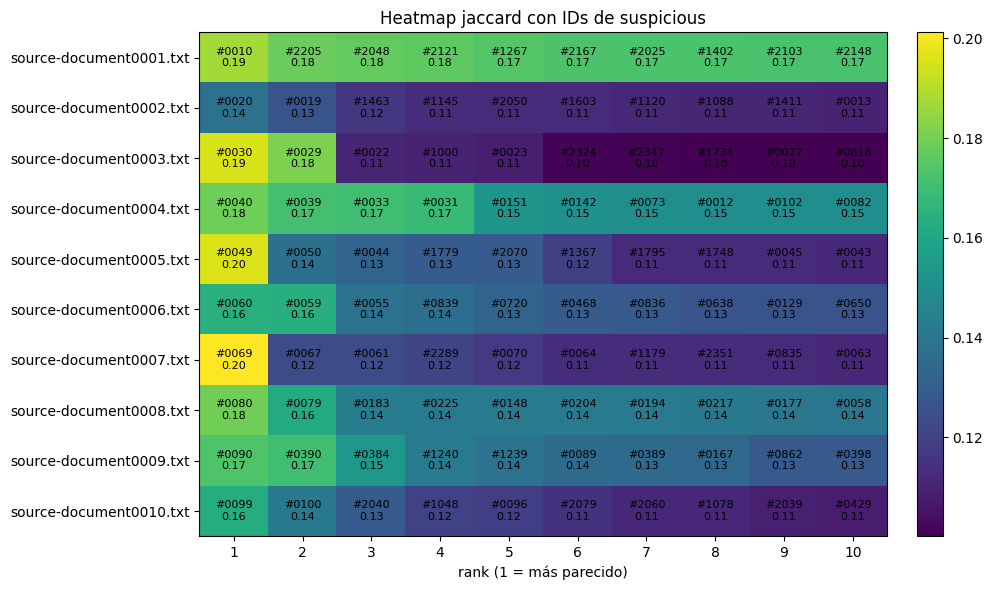

```python
plot_heatmap_with_labels(resultados, metric="jaccard")
```

La siguiente figura replica el análisis anterior pero usando la **métrica Dice**. Cada fila es un *source*, las columnas muestran su **top-10** de *suspicious* y en cada celda aparece el **ID** del *suspicious* y su **valor Dice**.

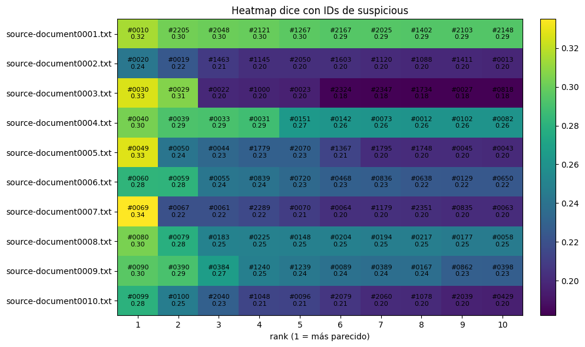

```python
plot_heatmap_with_labels(resultados, metric="dice")
```

# Conclusión

En conjunto, las similitudes por **Jaccard** y **Dice** muestran que los textos comparten tema y vocabulario, aunque solo algunos casos presentan señales fuertes; la mayoría exhibe solapamiento **moderado** y bastante **parejo** entre los diez candidatos.

Los **líderes más claros** aparecen en: `source-document0007.txt` con `suspicious-document0069.txt`, `source-document0005.txt` con `suspicious-document0049.txt`, `source-document0003.txt` con `suspicious-document0030.txt`, y `source-document0008.txt` con `suspicious-document0080.txt`. También hay similitudes, pero con brecha moderada, en `source-document0009.txt` (`suspicious-document0090.txt`) y `source-document0010.txt` (`suspicious-document0099.txt`).

El ranking con **Dice** mantiene esencialmente el mismo orden que con Jaccard.

**Documento en Colab** [enlace](https://colab.research.google.com/drive/1cXkWTf0yyjDNazccOPs27R_lxI4y4B7v?usp=sharing).

# Referencias

Ruiz Velázquez, L. G. (2025). *Unidad 4: Obtención de encajes vectoriales, modelo de espacio vectorial y medidas de similitud*. *Maestría en Ciencia de Datos e Información*, INFOTEC – Centro de Investigación e Innovación en Tecnologías de la Información y Comunicación.

Manning, C. D., Raghavan, P., & Schütze, H. (2008). *Introduction to information retrieval*. Cambridge University Press.